# iris

INTRODUCTION

The Iris dataset, consisting of measurements of iris flowers' sepal and petal length and width in centimeters, is a classic dataset in machine learning and data mining. In this analysis, we aim to apply K-means clustering to the Iris dataset to identify natural groupings or clusters within the data. Before applying K-means clustering, we will first select an appropriate number of clusters (K) using the elbow method, which involves plotting the within-cluster sum of squares against the number of clusters and identifying the point at which the rate of decrease in the sum of squares slows down, resembling an "elbow" shape. Once the optimal number of clusters is determined, we will proceed to apply K-means clustering to the dataset. After clustering, we will examine the characteristics of each cluster and assign meaningful names based on similarities with known iris species such as Iris-setosa, Iris-versicolor, and Iris-virginica, aiming to identify distinct groupings of iris flowers based on their sepal and petal measurements.

DATA UNDERSTANDING AND PREPROCESSING

Summary Statistics: Calculate descriptive statistics such as mean, median, standard deviation, and range for each numerical feature (sepal length, sepal width, petal length, and petal width) to understand their central tendencies and variability.

Feature Visualization: Plot histograms or box plots for each numerical feature to visualize their distributions and identify any skewness or outliers. Additionally, create scatter plots to explore relationships between pairs of features and gain insights into potential clustering patterns.

Class Distribution Analysis: Examine the distribution of the target variable (iris species) to ensure class balance or identify any class imbalances that may require addressing through techniques like oversampling or undersampling.

Missing Values Detection: Check for missing values in the dataset and decide on an appropriate strategy for handling them, such as imputation or removal, to ensure data completeness before clustering.

VARIABLES DESCRIPTION

SepalLengthCm: This variable denotes the length of the sepal (the outermost part of the flower)

SepalWidthCm: This variable represents the width of the sepal.

PetalLengthCm: This variable indicates the length of the petal (the inner part of the flower)

PetalWidthCm: This variable denotes the width of the petal.

UPLOAD AND CLEAN DATA

Step 1: Mount the drive

```python
from google.colab import drive
drive.mount('/content/drive')
```

Step 2: Import the necessary python libraries

```python
import pandas as pd
import seaborn as sns
from sklearn.cluster import KMeans
from collections import Counter
from sklearn import preprocessing
from matplotlib import pyplot as plt
```

Step 3: Read the data from Iris.csv file

```python
Iris = pd.read_csv("/content/drive/MyDrive/IS670_data/Iris.csv")
Iris
```

|  | SepalLengthCm | SepalWidthCm | PetalLengthCm | PetalWidthCm |
| --- | --- | --- | --- | --- |
| 0 | 7.9 | 3.8 | 6.4 | 2.0 |
| 1 | 7.7 | 3.8 | 6.7 | 2.2 |
| 2 | 7.7 | 3.0 | 6.1 | 2.3 |
| 3 | 7.7 | 2.8 | 6.7 | 2.0 |
| 4 | 7.7 | 2.6 | 6.9 | 2.3 |
| ... | ... | ... | ... | ... |
| 145 | 4.5 | 2.3 | 1.3 | 0.3 |
| 146 | 4.4 | 3.2 | 1.3 | 0.2 |
| 147 | 4.4 | 3.0 | 1.3 | 0.2 |
| 148 | 4.4 | 2.9 | 1.4 | 0.2 |
| 149 | 4.3 | 3.0 | 1.1 | 0.1 |

150 rows × 4 columns

Step 4: Display all the keys of the Iris dataset

```python
Iris.keys()
```

```
Index(['SepalLengthCm', 'SepalWidthCm', 'PetalLengthCm', 'PetalWidthCm'], dtype='object')
```

Step 5: Examine the first few rows of the dataset to have a better understanding

```python
Iris.head()
```

|  | SepalLengthCm | SepalWidthCm | PetalLengthCm | PetalWidthCm |
| --- | --- | --- | --- | --- |
| 0 | 7.9 | 3.8 | 6.4 | 2.0 |
| 1 | 7.7 | 3.8 | 6.7 | 2.2 |
| 2 | 7.7 | 3.0 | 6.1 | 2.3 |
| 3 | 7.7 | 2.8 | 6.7 | 2.0 |
| 4 | 7.7 | 2.6 | 6.9 | 2.3 |

Step 6: Display all the data types of the dataset

```python
Iris.dtypes
```

```
SepalLengthCm    float64
SepalWidthCm     float64
PetalLengthCm    float64
PetalWidthCm     float64
dtype: object
```

Step 7: Check for any missing values

```python
Iris.isnull().sum()
```

```
SepalLengthCm    0
SepalWidthCm     0
PetalLengthCm    0
PetalWidthCm     0
dtype: int64
```

Step 8: Show the statistics of numeric variables

```python
Iris.describe()
```

|  | SepalLengthCm | SepalWidthCm | PetalLengthCm | PetalWidthCm |
| --- | --- | --- | --- | --- |
| count | 150.000000 | 150.000000 | 150.000000 | 150.000000 |
| mean | 5.843333 | 3.054000 | 3.758667 | 1.198667 |
| std | 0.828066 | 0.433594 | 1.764420 | 0.763161 |
| min | 4.300000 | 2.000000 | 1.000000 | 0.100000 |
| 25% | 5.100000 | 2.800000 | 1.600000 | 0.300000 |
| 50% | 5.800000 | 3.000000 | 4.350000 | 1.300000 |
| 75% | 6.400000 | 3.300000 | 5.100000 | 1.800000 |
| max | 7.900000 | 4.400000 | 6.900000 | 2.500000 |

Step 9: Generate the correlation of all numeric variables

```python
Iris.corr()
```

|  | SepalLengthCm | SepalWidthCm | PetalLengthCm | PetalWidthCm |
| --- | --- | --- | --- | --- |
| SepalLengthCm | 1.000000 | -0.109369 | 0.871754 | 0.817954 |
| SepalWidthCm | -0.109369 | 1.000000 | -0.420516 | -0.356544 |
| PetalLengthCm | 0.871754 | -0.420516 | 1.000000 | 0.962757 |
| PetalWidthCm | 0.817954 | -0.356544 | 0.962757 | 1.000000 |

Step 10: Generate the correlation matrix of all numeric variables

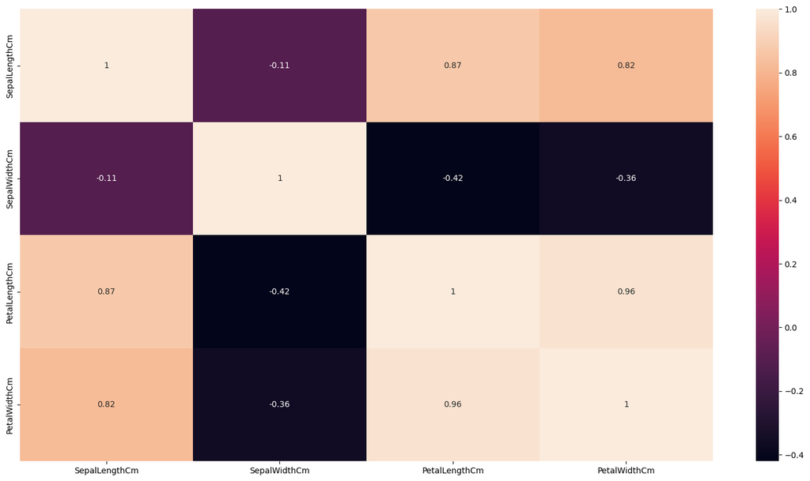

```python
plt.figure(figsize=[19,10])
sns.heatmap(Iris.corr(),annot=True)
```

Step 11: Countplot of variable SepalWidthCm

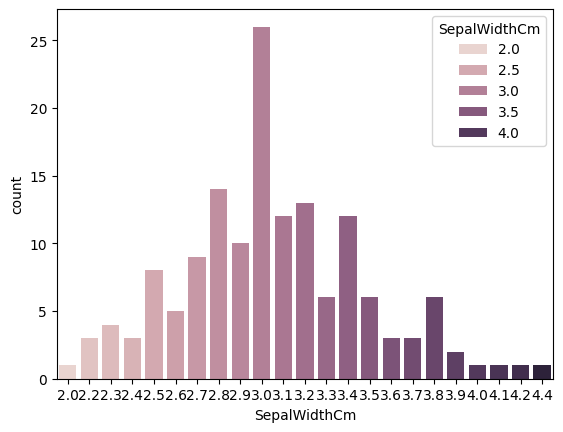

```python
sns.countplot(x=Iris['SepalWidthCm'],hue=Iris['SepalWidthCm'])
plt.figure(figsize=(10, 20))
```

The count plot visualizes the distribution of sepal widths in the Iris dataset, with each bar representing the frequency of a particular width, and the colors indicating the same width category.

Step 12: Pairplot of all the variables

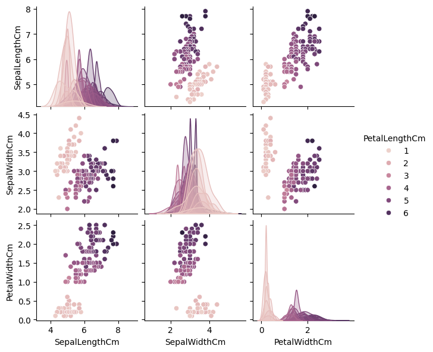

```python
plt.figure(figsize=(8, 6))
sns.pairplot(Iris, hue='PetalLengthCm', height=2)
plt.show()
```

The pair plot displays pairwise relationships between different variables in the Iris dataset, with hue indicating the variation in petal length.

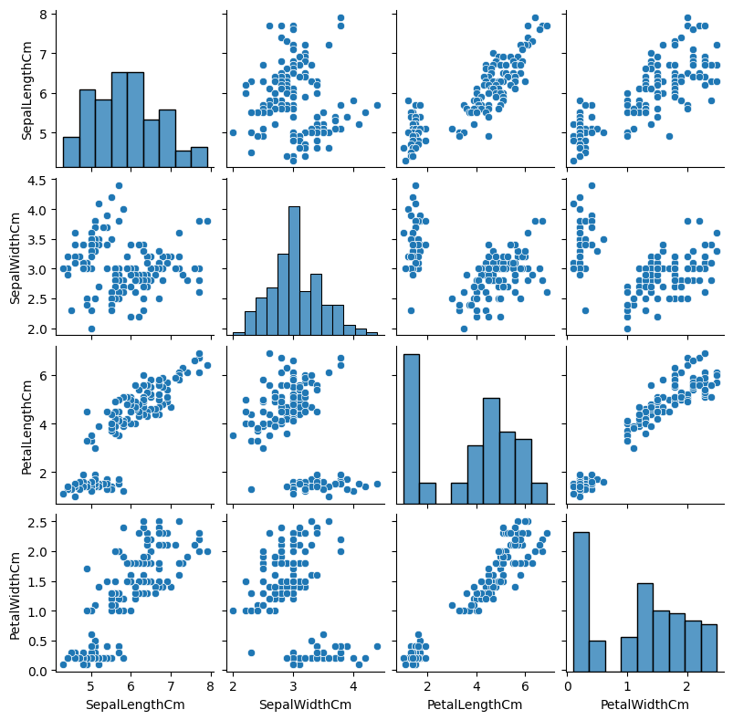

```python
sns.pairplot(Iris, height=2)
plt.figure(figsize=(8, 6))
```

Step 13: Scatter plot of all the variables

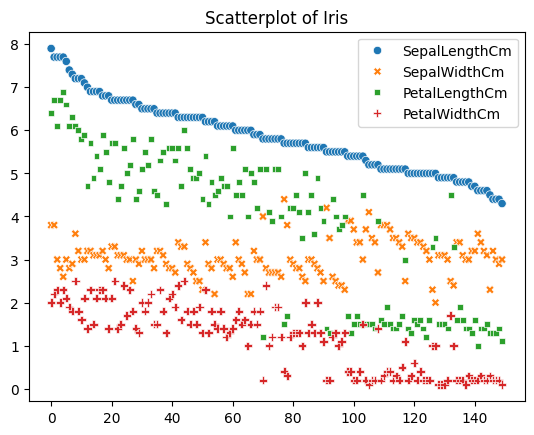

```python
snsplot = sns.scatterplot(data=Iris)
snsplot.set_title("Scatterplot of Iris")
```

Step 14: IQR of variable SepalWidthCm

```python
IQR = Iris['SepalWidthCm'].quantile(0.75) - Iris['SepalWidthCm'].quantile(0.25)
print("IQR:", IQR)
```

```
IQR: 0.5
```

Step 15: Apply minmax normalization

```python
min_max_scaler = preprocessing.MinMaxScaler()
Iris_normalized = pd.DataFrame(min_max_scaler.fit_transform(Iris))
Iris.columns = Iris.columns
Iris_normalized
```

|  | 0 | 1 | 2 | 3 |
| --- | --- | --- | --- | --- |
| 0 | 1.000000 | 0.750000 | 0.915254 | 0.791667 |
| 1 | 0.944444 | 0.750000 | 0.966102 | 0.875000 |
| 2 | 0.944444 | 0.416667 | 0.864407 | 0.916667 |
| 3 | 0.944444 | 0.333333 | 0.966102 | 0.791667 |
| 4 | 0.944444 | 0.250000 | 1.000000 | 0.916667 |
| ... | ... | ... | ... | ... |
| 145 | 0.055556 | 0.125000 | 0.050847 | 0.083333 |
| 146 | 0.027778 | 0.500000 | 0.050847 | 0.041667 |
| 147 | 0.027778 | 0.416667 | 0.050847 | 0.041667 |
| 148 | 0.027778 | 0.375000 | 0.067797 | 0.041667 |
| 149 | 0.000000 | 0.416667 | 0.016949 | 0.000000 |

150 rows × 4 columns

MODEL DEVELOPMENT

Step 16: Build a clustering model with n_clusters = 2. Set random_state=0.

```python
model = KMeans(n_clusters=2, random_state=0)
model.fit(Iris_normalized)
```

```
KMeans(n_clusters=2, random_state=0)
```

Step 17:Generate the cluster labels

```python
labels = model.labels_
```

Step 18: Show cluster size

```python
Counter(model.labels_)
```

```
Counter({0: 100, 1: 50})
```

Step 19: Show cluster centroids

```python
pd.DataFrame({'Iris-versicolor':Iris[model.labels_==0].mean(axis=0), 'Iris-setosa':Iris[model.labels_==1].mean(axis=0)})
```

|  | Iris-versicolor | Iris-setosa |
| --- | --- | --- |
| SepalLengthCm | 6.262 | 5.006 |
| SepalWidthCm | 2.872 | 3.418 |
| PetalLengthCm | 4.906 | 1.464 |
| PetalWidthCm | 1.676 | 0.244 |

From above, cluster 1 is named Iris - versicolor. Cluster 2 is Iris Setosa.

"Iris-versicolor" is aptly named for its varied coloration, as "versicolor" denotes "variously colored" in Latin. This iris species showcases a spectrum of hues, ranging from blues and purples to occasional pinks, aligning well with its nomenclature.

"Iris-setosa" derives its name from its notable setae, which are hair-like structures present on its leaves and stems. "Setosa" translates to "bristly" or "hairy" in Latin, accurately describing the physical attributes of this particular iris species.

STep 20: Elbow test to determine optimal number of clusters

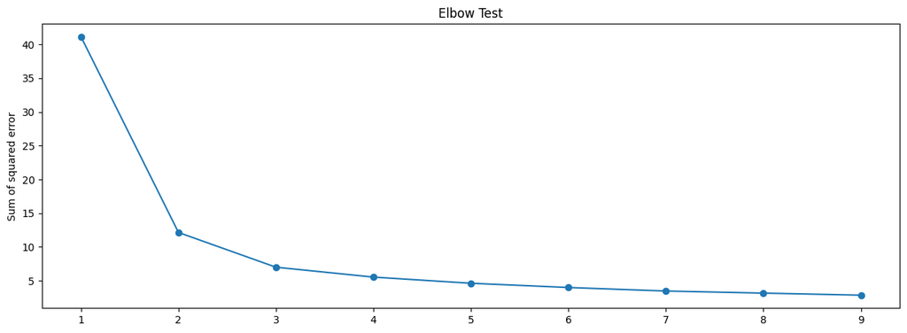

```python
Sum_of_squared_error = []
for k in range(1, 10):
    kmeans = KMeans(n_clusters=k)
    kmeans.fit(Iris_normalized)
    Sum_of_squared_error.append(kmeans.inertia_)

fig = plt.figure(figsize=(15, 5))
plt.scatter(range(1, 10), Sum_of_squared_error)
plt.plot(range(1, 10), Sum_of_squared_error)
plt.ylabel('Sum of squared error')
plt.title('Elbow Test')
```

From the above elbow method graph, optimal K value is 2

Build a clustering model with n_clusters = 3. Set random_state=0. Find the centroids

```python
model = KMeans(n_clusters=3, random_state=0)
model.fit(Iris_normalized)
```

```
KMeans(n_clusters=3, random_state=0)
```

```python
pd.DataFrame({'Iris-versicolor':Iris[model.labels_==0].mean(axis=0),'Iris-setosa':Iris[model.labels_==1].mean(axis=0), 'Iris-virginica':Iris[model.labels_==2].mean(axis=0)})
```

|  | Iris-versicolor | Iris-setosa | Iris-virginica |
| --- | --- | --- | --- |
| SepalLengthCm | 5.888525 | 5.006 | 6.846154 |
| SepalWidthCm | 2.737705 | 3.418 | 3.082051 |
| PetalLengthCm | 4.396721 | 1.464 | 5.702564 |
| PetalWidthCm | 1.418033 | 0.244 | 2.079487 |

Cluster 1 (Iris-versicolor):

This cluster aligns with the attributes of Iris-versicolor. Iris-versicolor typically exhibits moderate sepal lengths, narrower sepals compared to Iris-setosa, and medium-sized petals with a relatively larger width. These attributes suggest a profile consistent with Iris-versicolor.

Cluster 3 (Iris-virginica):

This cluster corresponds to Iris-virginica species. Iris-virginica is characterized by longer sepal and petal dimensions compared to Iris-versicolor and Iris-setosa. The larger sepal and petal sizes, along with a wider petal width, indicate a profile typical of Iris-virginica.

Bar chart of the cluster variables

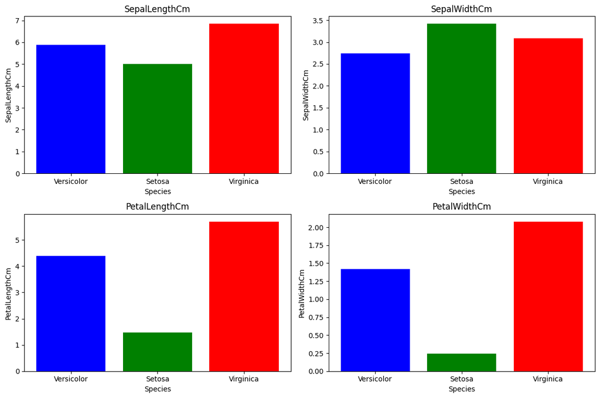

```python
import matplotlib.pyplot as plt

# Mean values for each feature within each cluster
versicolor_means = [5.888525, 2.737705, 4.396721, 1.418033]
setosa_means = [5.006, 3.418, 1.464, 0.244]
virginica_means = [6.846154, 3.082051, 5.702564, 2.079487]

# Feature names
features = ['SepalLengthCm', 'SepalWidthCm', 'PetalLengthCm', 'PetalWidthCm']

# Cluster labels
labels = ['Versicolor', 'Setosa', 'Virginica']

# Plot
fig, ax = plt.subplots(2, 2, figsize=(12, 8))

for i in range(4):
    row = i // 2
    col = i % 2
    ax[row, col].bar(labels, [versicolor_means[i], setosa_means[i], virginica_means[i]], color=['blue', 'green', 'red'])
    ax[row, col].set_xlabel('Species')
    ax[row, col].set_ylabel(features[i])
    ax[row, col].set_title(features[i])

plt.tight_layout()
plt.show()
```

This grouped bar chart visualizes the mean values of sepal and petal dimensions for each iris species: Versicolor, Setosa, and Virginica. The distinct color coding allows for easy comparison of feature measurements across different species.

Scatterplot of all the cluster variables

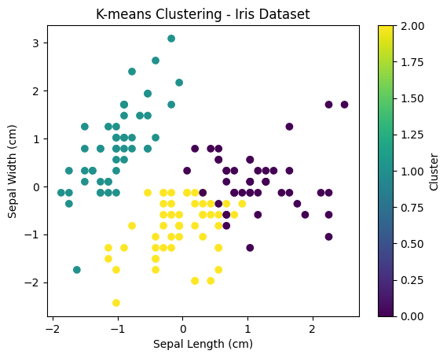

```
         sepal length (cm)  sepal width (cm)  petal length (cm)  \
Cluster
0                 6.780851          3.095745           5.510638
1                 5.006000          3.428000           1.462000
2                 5.801887          2.673585           4.369811

         petal width (cm)
Cluster
0                1.972340
1                0.246000
2                1.413208
```

```python
from sklearn.datasets import load_iris
from sklearn.preprocessing import StandardScaler

# Load the Iris dataset
iris = load_iris()
X = iris.data

# Standardize the features
scaler = StandardScaler()
X_scaled = scaler.fit_transform(X)

# Apply K-means clustering
kmeans = KMeans(n_clusters=3, random_state=42)
kmeans.fit(X_scaled)

# Assign labels to each data point
labels = kmeans.labels_

# Add the cluster labels to the original dataset
iris_df = pd.DataFrame(data=iris.data, columns=iris.feature_names)
iris_df['Cluster'] = labels

# Visualize the clusters
plt.scatter(X_scaled[:, 0], X_scaled[:, 1], c=labels, cmap='viridis')
plt.xlabel('Sepal Length (cm)')
plt.ylabel('Sepal Width (cm)')
plt.title('K-means Clustering - Iris Dataset')
plt.colorbar(label='Cluster')
plt.show()

# Analyze the characteristics of each cluster
cluster_centers = scaler.inverse_transform(kmeans.cluster_centers_)
cluster_df = pd.DataFrame(data=cluster_centers, columns=iris.feature_names)
cluster_df.index.name = 'Cluster'
print(cluster_df)

# Classify clusters as Iris-setosa, Iris-versicolor, and Iris-virginica
# Based on the characteristics of the clusters and comparing them to known species attributes
# (e.g., sepal length, sepal width, petal length, petal width)
# You can use domain knowledge or conduct further analysis to determine the appropriate labels for each cluster
```

Scatter Plot of cluster variables based on Principal Component Analysis

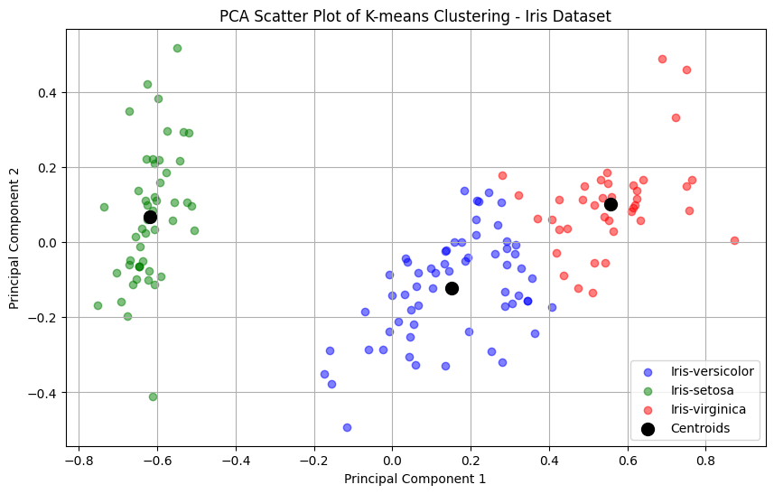

```python
from sklearn.decomposition import PCA
from sklearn import preprocessing

pca = PCA(n_components=2)
Iris_pca = pca.fit_transform(Iris_normalized)

plt.figure(figsize=(10, 6))

plt.scatter(Iris_pca[model.labels_ == 0, 0], Iris_pca[model.labels_ == 0, 1], color='blue', label='Iris-versicolor', alpha=0.5)
plt.scatter(Iris_pca[model.labels_ == 1, 0], Iris_pca[model.labels_ == 1, 1], color='green', label='Iris-setosa', alpha=0.5)
plt.scatter(Iris_pca[model.labels_ == 2, 0], Iris_pca[model.labels_ == 2, 1], color='red', label='Iris-virginica', alpha=0.5)

centroids = pca.transform(model.cluster_centers_)
plt.scatter(centroids[:, 0], centroids[:, 1], marker='o', color='black', label='Centroids', s=100)

plt.xlabel('Principal Component 1')
plt.ylabel('Principal Component 2')
plt.title('PCA Scatter Plot of K-means Clustering - Iris Dataset')
plt.legend()
plt.grid(True)
plt.show()
```

EVALUATION AND PERFORMANCE

MODEL k=2: It might be preferable when seeking to simplify complex data or when looking for clear boundaries between two main groups. This could be useful in scenarios like customer segmentation where dividing customers into two broad categories might suffice.

MODEL k=3: This could be more suitable when there are indications or domain knowledge suggesting the presence of three distinct subgroups within the data. For example, in market research, if there are three distinct segments of customers based on purchasing behavior, k=3 clustering could reveal these segments effectively.

CONCLUSION

In conclusion, the choice between k=2 and k=3 for clustering depends on the underlying structure of the data and the specific objectives of the analysis. K=2 clustering is favored for simpler, binary categorizations, while k=3 clustering is preferred when there are indications or domain knowledge suggesting the presence of three distinct subgroups within the data. Ultimately, the decision should be guided by the insights sought and the interpretability of the resulting clusters in addressing the problem at hand.

```python
!jupyter nbconvert --to html "/content/drive/MyDrive/Colab Notebooks/iris.ipynb"
```

```
[NbConvertApp] Converting notebook /content/drive/MyDrive/Colab Notebooks/iris.ipynb to html
[NbConvertApp] Writing 649009 bytes to /content/drive/MyDrive/Colab Notebooks/iris.html
```